# Visualizing data distributions

## 9.16 ggplot2 geometries

### 9.16.1 Barplots

To generate a barplot we can use the `geom_bar` geometry:

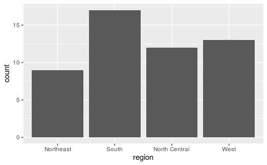

```r
murders %>%
  ggplot(aes(region)) +
  geom_bar()
```

We often already have a table with a distribution that we want to present as barplot:

```r
data(murders)
tab <- murders %>%
  count(region) %>%
  mutate(proportion = n/sum(n))
tab
```

| region | n | proportion |
| --- | --- | --- |
| Northeast | 9 | 0.1764706 |
| South | 17 | 0.3333333 |
| North Central | 12 | 0.2352941 |
| West | 13 | 0.2549020 |

And we can change with it:

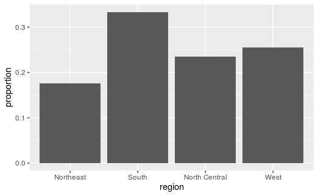

```r
tab %>%
  ggplot(aes(region, proportion)) +
  geom_bar(stat = "identity")
```

### 9.16.2 Histograms

To generate histograms we use `geom_histogram`.

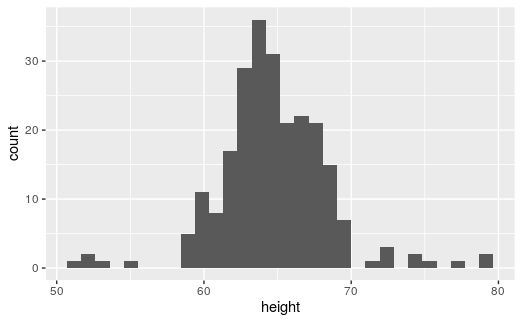

```r
heights %>%
  filter(sex == "Female") %>%
  ggplot(aes(height)) +
  geom_histogram()
```

Then we get a message > `stat_bin()` using `bins = 30`. Pick better value with `binwidth`.

So:

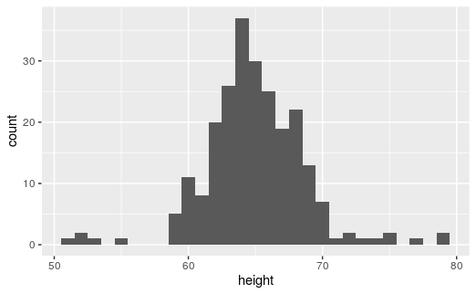

```r
heights %>%
  filter(sex == "Female") %>%
  ggplot(aes(height)) +
  geom_histogram(binwidth = 1)
```

And we give some more labels like title and color and so on:

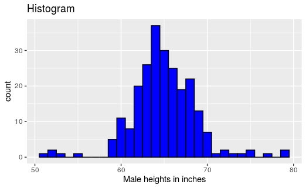

```r
heights %>%
  filter(sex == "Female") %>%
  ggplot(aes(height)) +
  geom_histogram(binwidth = 1, fill = "blue", col = "black") +
  xlab("Male heights in inches") +
  ggtitle("Histogram")
```

### 9.16.3 Density plots

To create a smooth density, we use the `geom_density`:

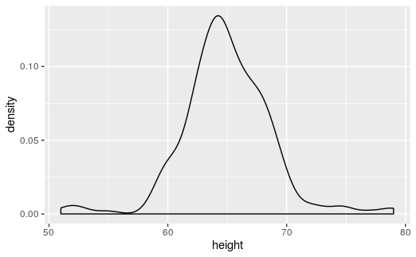

```r
heights %>%
  filter(sex == "Female") %>%
  ggplot(aes(height)) +
  geom_density()
```

To fill in with color, we can use the argument `fill`:

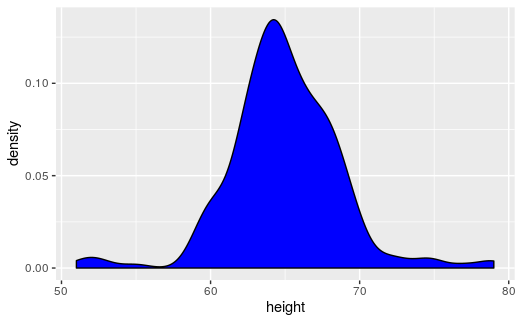

```r
heights %>%
  filter(sex == "Female") %>%
  ggplot(aes(height)) +
  geom_density(fill="blue")
```

To change the smoothness of the density, we use the argument `adjust`:

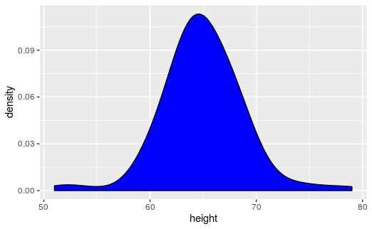

```r
heights %>%
  filter(sex == "Female") %>%
  ggplot(aes(height)) +
  geom_density(fill = "blue", adjust = 2)
```

### 9.16.4 Boxplots

The geometry for boxplot is `geom_boxplot`:

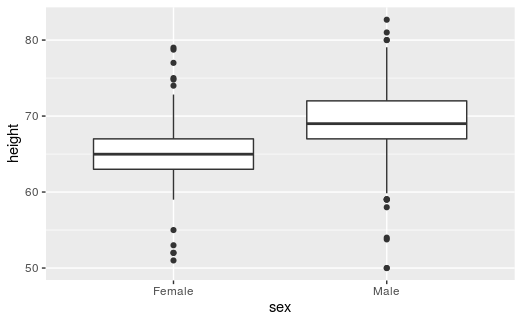

```r
heights %>%
  ggplot(aes(sex, height)) +
  geom_boxplot()
```

### 9.16.5 QQ-plots

For qq-plots we use the geometry `geom_qq`:

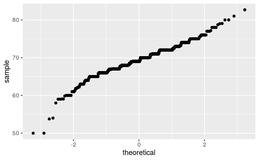

```r
heights %>%
  filter(sex=="Male") %>%
  ggplot(aes(sample = height)) +
  geom_qq()
```

By default, the sample variable is compared to a normal distribution with average 0 and standard deviation 1. To change this, we use the argument `dparams`. Adding an identity line is as simple as assigning another layer. For straight lines, we use the function `geom_abline`.

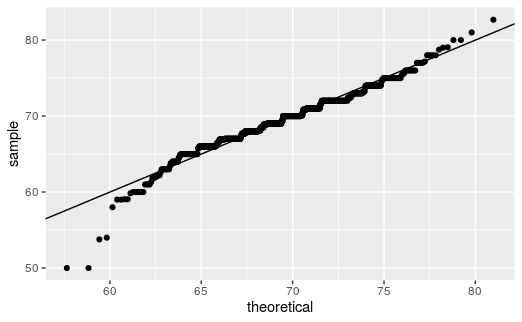

```r
params <- heights %>%
  filter(sex=="Male") %>%
  summarize(mean = mean(height), sd = sd(height))

heights %>%
  filter(sex=="Male") %>%
  ggplot(aes(sample = height)) +
  geom_qq(dparams = params) +
  geom_abline()
```

Another option here is to scale the data first and then make a qqplot against the standard normal.

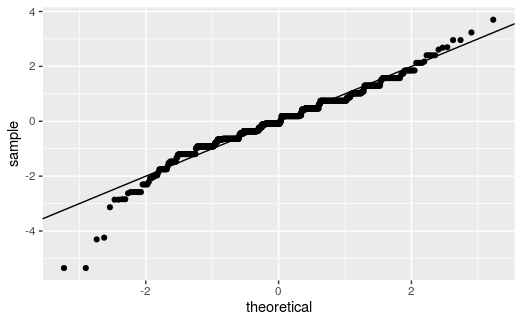

```r
heights %>%
  filter(sex=="Male") %>%
  ggplot(aes(sample = scale(height))) +
  geom_qq() +
  geom_abline()
```

### 9.16.6 Images

Images were not needed for the concepts described in this chapter, but we will use images at later. The two geometries used to create images: `geom_tile` and `geom_raster`.

For example, here is a data frame about `x` and `y`:

```r
x <- expand.grid(x = 1:12, y = 1:10) %>%
  mutate(z = 1:120)
```

It is a tidy version of `matrix(1:120, 12, 10)`

To plot the image we use the following code:

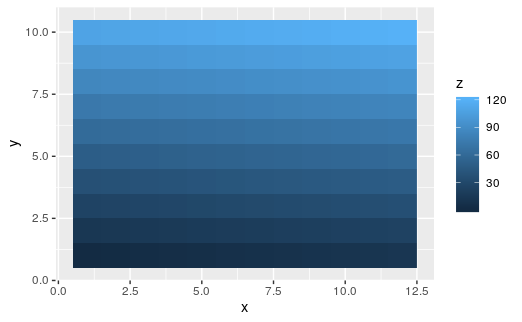

```r
x %>% ggplot(aes(x, y, fill = z)) +
  geom_raster()
```

With these images you will often want to change the color scale. This can be done through the `scale_fill_gradientn layer`.

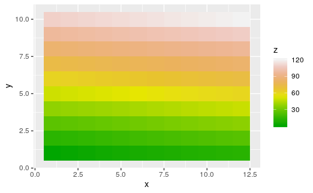

```r
x %>%
  ggplot(aes(x, y, fill = z)) +
  geom_raster() +
  scale_fill_gradientn(colors =  terrain.colors(10))
```

### 9.16.7 Quick plots

```r
x <- heights %>%
  filter(sex=="Male") %>%
  pull(height)
```

To make a quick histogram we can use:

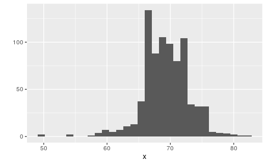

```r
qplot(x)
```

To make a quick qqplot you have to use the argument `sample`:

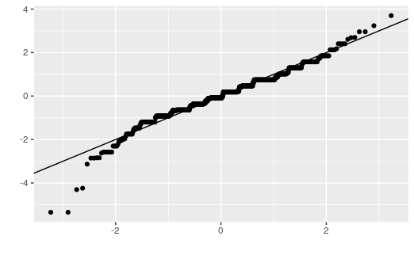

```r
qplot(sample = scale(x)) +
  geom_abline()
```

If we supply a factor and a numeric vector, we obtain a plot like the below. Note that in the code below we are using the argument `data`:

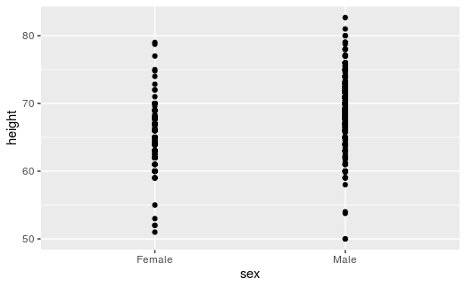

```r
heights %>% qplot(sex, height, data = .)
```

We can also select a specific geometry by using the argument `geom`:

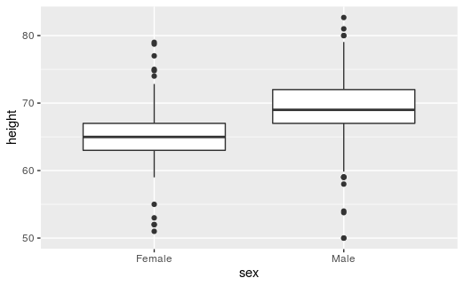

```r
heights %>% qplot(sex, height, data = ., geom = "boxplot")
```

We can also use the argument `geom` to generate a density plot instead of a histogram:

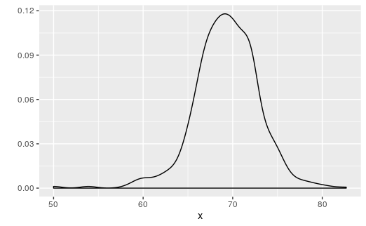

```r
qplot(x, geom = "density")
```

Although not as much as with `ggplot`, we do have some flexibility to improve the results of `qplot`:

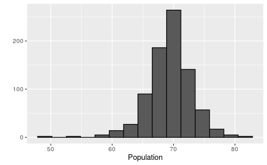

```r
qplot(x, bins=15, color = I("black"), xlab = "Population")
```

## 9.17 Exercises

1. Now we are going to use the `geom_histogram` function to make a histogram of the heights in the `height` data frame. When reading the documentation for this function we see that it requires just one mapping, the values to be used for the histogram. Make a histogram of all the plots.

What is the variable containing the heights?

D. heights$height

2. Now create a ggplot object using the pipe to assign the heights data to a ggplot object. Assign `height` to the x values through the `aes` function.

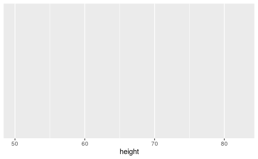

```r
heights %>% ggplot(aes(height))
```

3. Now we are ready to add a layer to actually make the histogram. Use the object created in the previous exercise and the `geom_histogram` function to make the histogram.

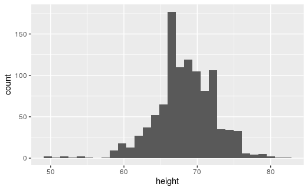

```r
heights %>% ggplot(aes(height)) +
  geom_histogram()
```

4. Note that when we run the code in the previous exercise we get the warning: `stat_bin() using bins = 30`. Pick better value with `binwidth`.

Use the `binwidth` argument to change the histogram made in the previous exercise to use bins of size 1 inch.

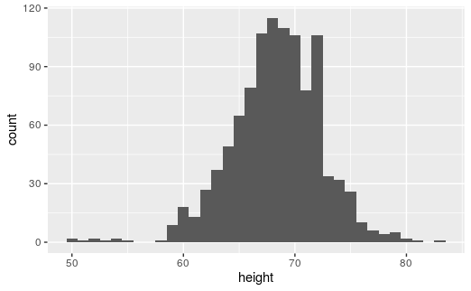

```r
heights %>% ggplot(aes(height)) +
  geom_histogram(binwidth = 1)
```

5. Instead of a histogram, we are going to make a smooth density plot. In this case we will not make an object, but instead render the plot with one line of code. Change the geometry in the code previously used to make a smooth density instead of a histogram.

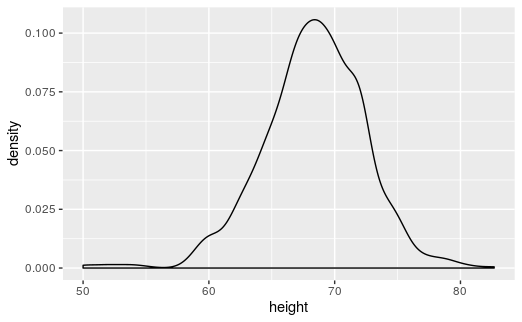

```r
heights %>% ggplot(aes(height)) +
  geom_density()
```

6. Now we are going to make a density plot for males and females separately. We can do this using the `group` argument. We assign groups via the aesthetic mapping as each point needs to a group before making the calculations needed to estimate a density.

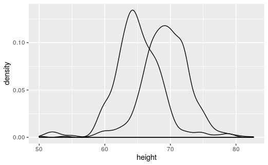

```r
heights %>% ggplot(aes(height, group = sex)) +
  geom_density()
```

7. We can also assign groups through the `color` argument. This has the added benefit that it uses color to distinguish the groups. Change the code above to use color

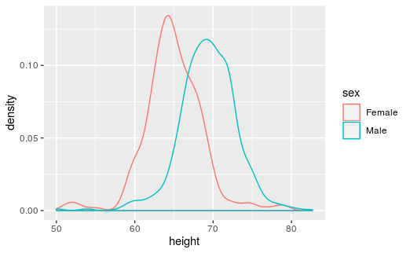

```r
heights %>% ggplot(aes(height, group = sex, color = sex)) +
  geom_density()
```

8. We can also assign groups through the `fill` argument. This has the added benefit that it uses colors to distinguish the groups, like this:

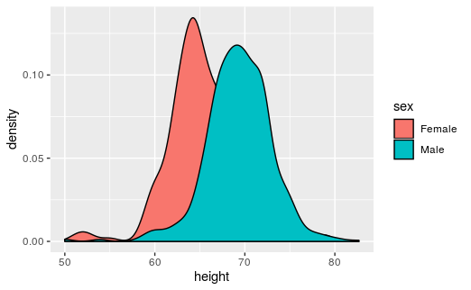

```r
heights %>%
  ggplot(aes(height, fill = sex)) +
  geom_density()
```

However, here the second density is drawn over the other. We can make the curves more visible by using alpha blending to add transparency. Set the `alpha` parameter to 0.2 in the `geom_density` function to make this change.

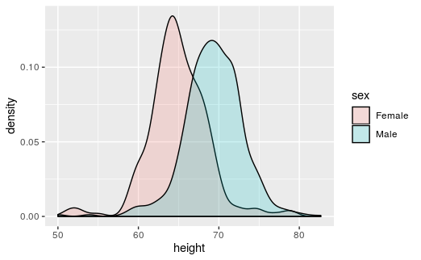

```r
heights %>%
  ggplot(aes(height, fill = sex)) +
  geom_density(alpha = 0.2)
```